# Digital Gene Expression (Second Experiment)

Artem Sokolov

## Total number of transcript counts that map to each well

We begin by quantifying the number of transcripts that mapped to each well. The plot below shows the distribution of counts across 384 wells for the two plates. The old P11 probe is highlighted in the original plate.

[output not shown]

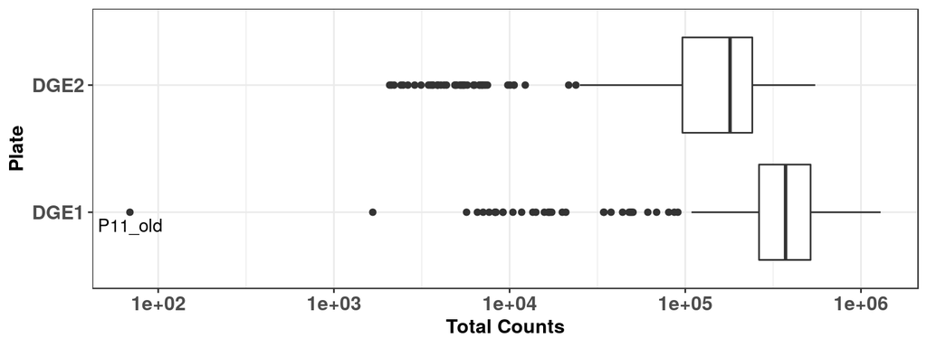

Overall, we observe that the old plate had a higher number of transcripts per well. This could be due to the difference in the set of drugs profiled in the two experiments. We repeat the quantification after reducing the set of wells for each plate down to the common set of treatments.

```
##
Downloading  [####################]100.00%   6.9kB/6.9kB (10.9MB/s) wrangled-meta.csv Done...
```

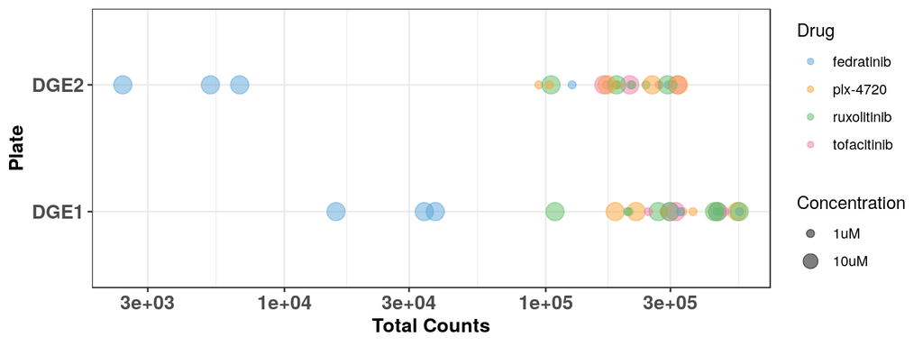

However, even for the common set of drugs/concentrations, we observe that the original plate had a slightly higher number of transcripts that mapped to each well.

## Correlation between replicates within and across plates

Next, we look at how well the expression profiles correlate across replicates, both within and across the two plates. The table below shows average Pearson correlation values for each Drug / Concentration pair.

| Drug | Conc. | Within1 | Within2 | Across |
| --- | --- | --- | --- | --- |
| fedratinib | 1 | 0.986 | 0.983 | 0.864 |
| plx-4720 | 1 | 0.981 | 0.933 | 0.797 |
| ruxolitinib | 1 | 0.989 | 0.990 | 0.870 |
| tofacitinib | 1 | 0.988 | 0.992 | 0.889 |
| fedratinib | 10 | 0.980 | 0.954 | 0.811 |
| plx-4720 | 10 | 0.970 | 0.975 | 0.883 |
| ruxolitinib | 10 | 0.979 | 0.848 | 0.804 |
| tofacitinib | 10 | 0.990 | 0.993 | 0.875 |

In general, the replicates on the second plate are just as internally consistent as the replicates on the first plate. As expected, the consistency of replicates across the two plates is lower.

We also look at whether transcriptional profiles cluster by treatment or by plate.

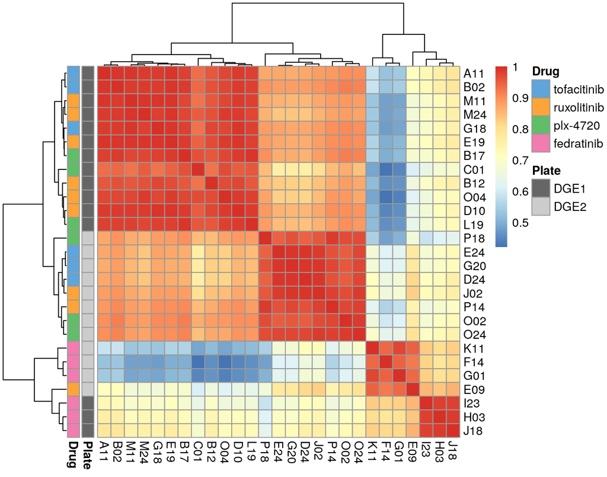

We note that for the most part samples cluster according to their source plate, rather than treatment. This suggests that each plate should be processed independently, as the batch effect prevents pooling of the data without any correction.

## DMSO controls on the second plate

Lastly, we check the DMSO wells on the second plate for internal consistency

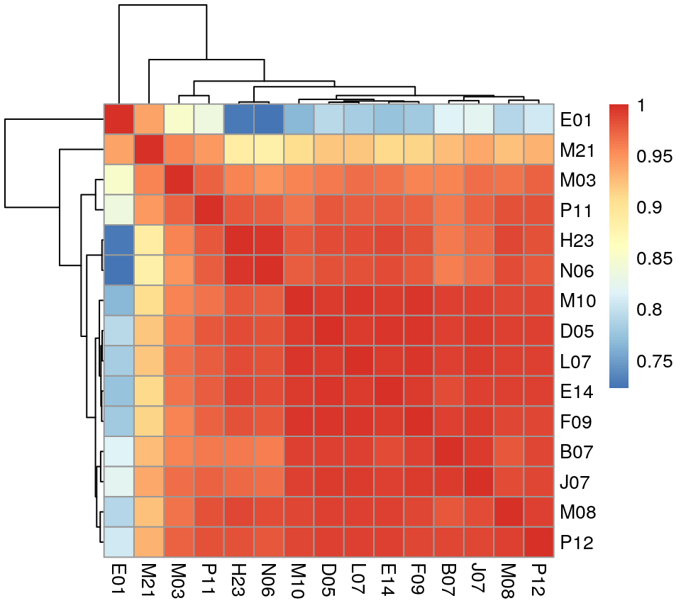

We observe that wells E01 and M21 appear to be slight outliers and recommend their exclusion from the analysis.

## Comparison of differential gene expression signatures

In general, correlation between full-transcriptome profiles of log fold-change values is pretty low. This is expected, since a large number of genes are not substantially perturbed by the corresponding treatments. Instead, we identify the genes that were significantly (FDR < 0.05) differentially expressed between treatment and controls on each plate. We then compute how many of these were in common between the two plates.

| Drug | Plate1 | Plate2 | InCommon |
| --- | --- | --- | --- |
| fedratinib | 1217 | 366 | 250 |
| plx-4720 | 121 | 136 | 31 |
| ruxolitinib | 323 | 41 | 32 |
| tofacitinib | 286 | 49 | 40 |